# Exercise 4_2: Subsetting and Linking

Geodata & Spatial Regression

Author

Anne-Kathrin Stroppe, Dennis Abel

### Exercises

**Note🏋 Exercise 1**

In this exercise, you will combine administrative boundary data with OpenStreetMap point data to explore the spatial distribution of dentists and veterinarians in Cologne and its surrounding districts.

First, load and prepare the German district shapefile, transform it to an appropriate projected coordinate reference system, and extract Cologne (`AGS == "05315"`) together with its neighbouring districts.

Then, use the bounding box of this study area (in WGS84!) to query OpenStreetMap for amenities tagged as dentists or veterinary practices. After cleaning the retrieved data and retaining only point geometries with valid amenity information, transform the OSM data to match the CRS of the district boundaries. Finally, create a map with `ggplot2` that shows the Cologne region and its surrounding districts, with dentists and veterinarians displayed as color-coded point features.

**Caution💡 Tip**

Pay attention to the different spatial data formats and coordinate reference systems used in this workflow. The district boundaries are read from a shapefile, while the amenity data are downloaded from OpenStreetMap and may contain several geometry types, such as points, lines, and polygons. For this exercise, you only need the `osm_points` object. Make sure to remove missing values in the amenity variable before plotting, and always transform the OSM point data to the same CRS as the district polygons before combining both layers in one `ggplot()` map. You need the function `sf::st_transform()` to change the CRS.

**Note🏋 Exercise 2**

In the second part of the exercise, you will move from mapping individual dentists and veterinarians to comparing their relative availability across Cologne and its surrounding districts.

To do this, spatially join the point data to the district polygons so that each amenity point receives the district identifier of the polygon in which it is located.

Then, count the number of dentists and veterinarians separately for each district and combine these counts with district-level population data.

Use the population values from our district-attribute table to calculate amenity densities per 100,000 inhabitants, which allows comparison between districts of different population sizes.

Finally, reshape the resulting table so that the density values can be attached back to the district geometries, and create choropleth maps showing the spatial variation in dentist and veterinary densities across the study area.

**Caution💡 Tip**

The main challenge in this task is to move between spatial and tabular operations in the correct order. Use `st_join()` with st_within to assign each point to the district polygon that contains it. Use `st_drop_geometry()` when you no longer need the point geometries and want to perform ordinary table operations. Use `filter()` to remove points that were not matched to any district, and `count()` to calculate the number of amenities by district and amenity type. Use `pivot_wider()` to create one density column for dentists and one for veterinarians before joining the results back to the district shapefile.

**Note🏋 Exercise 3**

To wrap up, let’s do some stuff with other data formats. Sample 50 points that fall within the boundaries of the city of Cologne.

**Caution💡 Tip**

Sampling is straightforward: Apply the `sf::st_sample` to the Cologne vector data, but make sure to apply the `sf::st_as_sf()` function afterward to receive a full-fledged data table (with a geometry column only).

**Note🏋 Exercise 4**

Create a new raster layer comprising Cologne’s immigrant rates based on the raster layers from the previous exercises. Extract the immigrant rate value at each position of the previously sampled points as a vector. What is your observation?

**Caution💡 Tip**

You need the `citizens_cologne.tif` and `inhabitants_cologne.tif` files in the `./data` folder. Due to severe data protection measures, the German Census 2012 data could be quite sparse.

**Note🏋 Exercise 5**

Use an adequate method of raster extraction to gather information in the geographic surroundings of a point. What is your observation now?

**Caution💡 Tip**

Assume that people move in a 1,000-meter radius around their location. Thus, extracting information on buffers of 1,000 meters around the points might be interesting using the option `sf::st_buffer()` function. In that case, you should also set a descriptive statistics function, e.g., with the option `fun = mean` and its helpful companion option to consider missing values `na.rm = TRUE`.

### Solutions

**Tip✅ Solution 1**

```r
# load packages
library(sf)
library(dplyr)
library(ggplot2)
library(patchwork)

# Import data
german_districts <-
  sf::read_sf("./data/VG250_KRS.shp") |>
  sf::st_transform(3035) |>
  dplyr::select(AGS, GEN)

# filter Cologne
cologne <-
  german_districts |>
  dplyr::filter(AGS == "05315")

# filter surrounding districts and append with Cologne data
cologne_sur <-
  german_districts |>
  dplyr::filter(lengths(sf::st_touches(german_districts, cologne)) > 0) |>
  dplyr::bind_rows(cologne)

# Generate a bounding box for Cologne surroundings area and transform to WGS84
bbox <- sf::st_bbox(cologne_sur) |>
  sf::st_transform(crs = 4326)

# Access OSM data and retrieve all veterinarians for your region
osmdata::set_overpass_url("https://overpass-api.de/api/interpreter")

dents_vets <-
  osmdata::opq(bbox = bbox, timeout = 60) |>
  osmdata::add_osm_feature(
    key = "amenity",
    value = c("dentist", "veterinary")
  ) |>
  osmdata::osmdata_sf()

dents_vets
# Some larger facilities are probably stored as polygons and not points
# For this exercise, we ignore these but keep in mind that the same feature
# might be stored in different vector types.

# Store only the points vector and keep only the amenity variable and geometry, which
# stores whether the point represents a dentist or a veterinarian.
dents_vets <- dents_vets$osm_points |>
  select(amenity)

# The data also contains a few NAs. Filter these.
dents_vets <- dents_vets |>
  filter(!is.na(amenity))

# Plot the points in color-coding for both type and add the borders from the
# Cologne and neighbors shapefile. Keep in mind to align the CRS of both vector files
# before it.
dents_vets <-
  sf::st_transform(
    dents_vets,
    crs = sf::st_crs(cologne_sur)
  )

ggplot() +
  geom_sf(data = cologne_sur, fill = "grey95", color = "black") +
  geom_sf(data = dents_vets, aes(color = amenity), size = 1, alpha = .5) +
  theme_minimal()
```

```
Object of class 'osmdata' with:
                 $bbox : 50.5418522210655,6.41617129091562,51.3931633145446,7.69321547402236
        $overpass_call : The call submitted to the overpass API
                 $meta : metadata including timestamp and version numbers
           $osm_points : 'sf' Simple Features Collection with 2590 points
            $osm_lines : NULL
         $osm_polygons : 'sf' Simple Features Collection with 123 polygons
       $osm_multilines : NULL
    $osm_multipolygons : NULL
```

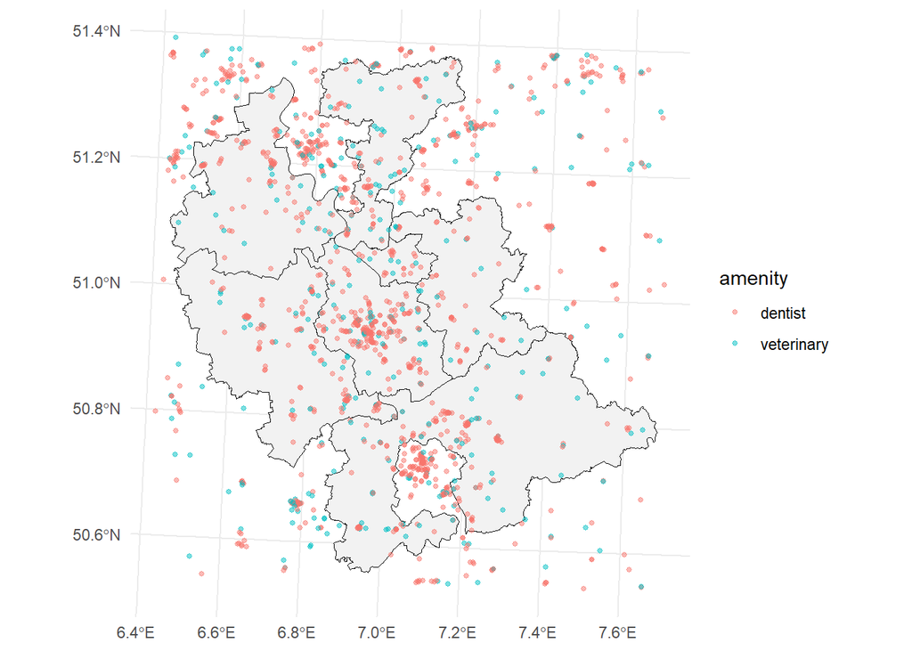

**Tip✅ Solution 2**

```r
# we want to understand the density of dentists and veterinarians for each of
# the seven districts. Count the number of points within each polygon (by type)
# and calculate as share of the population.

# We start by joining the districts to the points, which gives each point the
# district ID
points_with_AGS <- st_join(
  dents_vets,
  cologne_sur,
  join = st_within
)

points_with_AGS

# Count points by polygon and amenity type
point_counts <- points_with_AGS  |>
  st_drop_geometry() |>
  filter(!is.na(AGS)) |>
  count(AGS, amenity, name = "n")

point_counts

# Add population data from attribute table and calculate density by 100000 inhabitants
attributes_districts <-
  readr::read_delim("./data/attributes_districts.csv", delim = ";") |>
  select(population, AGS)

point_counts <-
  dplyr::left_join(point_counts, attributes_districts,
                   by = "AGS") |>
  dplyr::mutate(
    dens = (n*100000)/population
  )

point_counts

# Convert to wide format and attach to shapefiles
point_counts_wide <- point_counts |>
  select(!c(n, population)) |>
  tidyr::pivot_wider(
    names_from = amenity,
    values_from = dens,
    values_fill = 0,
    names_prefix = "dens_"
  )

point_counts_wide

# Attach your density values to your districts shapefile and plot both variables.
cologne_sur <- cologne_sur |>
  left_join(point_counts_wide, by = "AGS")

dentist_plot <- ggplot(cologne_sur) +
  geom_sf(aes(fill = dens_dentist)) +
  scale_fill_viridis_c() +
  theme_minimal()

veterinary_plot <- ggplot(cologne_sur) +
  geom_sf(aes(fill = dens_veterinary)) +
  scale_fill_viridis_c() +
  theme_minimal()

dentist_plot | veterinary_plot

cologne_sur_long <- cologne_sur |>
  tidyr::pivot_longer(
    cols = starts_with("dens_"),
    names_to = "amenity",
    values_to = "density"
  )

ggplot(cologne_sur_long) +
  geom_sf(aes(fill = density)) +
  facet_wrap(~ amenity) +
  theme_minimal()
```

```
Simple feature collection with 1521 features and 3 fields
Geometry type: POINT
Dimension:     XY
Bounding box:  xmin: 4068970 ymin: 3050834 xmax: 4158970 ymax: 3148436
Projected CRS: ETRS89-extended / LAEA Europe
First 10 features:
             amenity   AGS               GEN                geometry
241783240    dentist  <NA>              <NA> POINT (4097589 3128890)
250209988 veterinary  <NA>              <NA> POINT (4096684 3127018)
253374324    dentist  <NA>              <NA> POINT (4103770 3119284)
259198814    dentist 05315              Köln POINT (4107184 3096113)
263569422 veterinary  <NA>              <NA> POINT (4123567 3058833)
268249841    dentist 05315              Köln POINT (4099912 3108705)
287916528 veterinary 05382  Rhein-Sieg-Kreis POINT (4128345 3069684)
290011092 veterinary 05162 Rhein-Kreis Neuss POINT (4089377 3122173)
292273377 veterinary  <NA>              <NA> POINT (4071851 3080990)
299467564 veterinary  <NA>              <NA> POINT (4129488 3143920)
```

```
     AGS    amenity   n
1  05158    dentist  60
2  05158 veterinary  27
3  05162    dentist  68
4  05162 veterinary  22
5  05315    dentist 192
6  05315 veterinary  37
7  05316    dentist  20
8  05316 veterinary   5
9  05362    dentist  98
10 05362 veterinary  28
11 05378    dentist  42
12 05378 veterinary  14
13 05382    dentist 125
14 05382 veterinary  49
```

```
     AGS    amenity   n population      dens
1  05158    dentist  60     489794 12.250048
2  05158 veterinary  27     489794  5.512522
3  05162    dentist  68     457264 14.871059
4  05162 veterinary  22     457264  4.811225
5  05315    dentist 192    1084831 17.698609
6  05315 veterinary  37    1084831  3.410669
7  05316    dentist  20     165748 12.066511
8  05316 veterinary   5     165748  3.016628
9  05362    dentist  98     478126 20.496689
10 05362 veterinary  28     478126  5.856197
11 05378    dentist  42     286213 14.674386
12 05378 veterinary  14     286213  4.891462
13 05382    dentist 125     608335 20.547889
14 05382 veterinary  49     608335  8.054772
```

```
# A tibble: 7 × 3
  AGS   dens_dentist dens_veterinary
  <chr>        <dbl>           <dbl>
1 05158         12.3            5.51
2 05162         14.9            4.81
3 05315         17.7            3.41
4 05316         12.1            3.02
5 05362         20.5            5.86
6 05378         14.7            4.89
7 05382         20.5            8.05
```

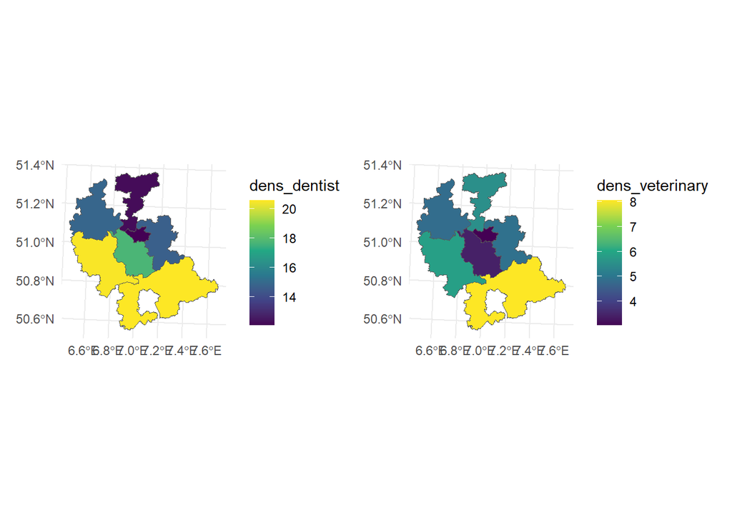

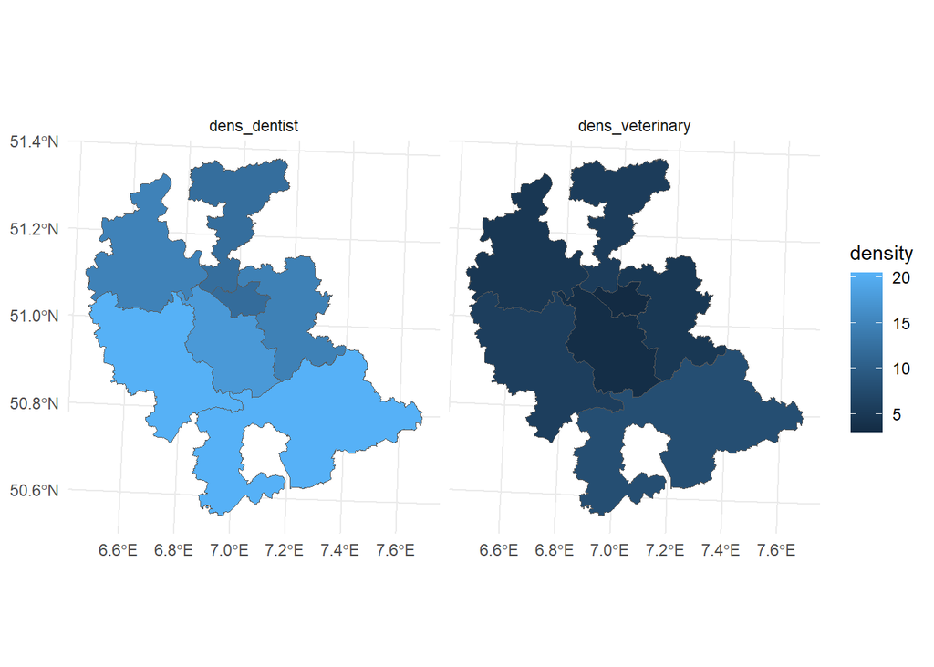

**Tip✅ Solution 3**

```r
cologne_50_points <-
  cologne |>
  sf::st_sample(50) |>
  sf::st_as_sf()
```

**Tip✅ Solution 4**

```r
library(terra)

# load all layers
citizens_cologne <- terra::rast("./data/citizens_cologne.tif")
inhabitants_cologne <- terra::rast("./data/inhabitants_cologne.tif")

# define missing values
citizens_cologne[citizens_cologne == -9] <- NA
inhabitants_cologne[inhabitants_cologne == -9] <- NA

# create immigrants layer
immigrants_cologne <- inhabitants_cologne - citizens_cologne

# something's off - let's get rid of the wierd negative numbers
immigrants_cologne[immigrants_cologne < 0] <- NA

immigrant_rates <-
  immigrants_cologne * 100 / inhabitants_cologne

immigrant_rates_at_point <- terra::extract(immigrant_rates, cologne_50_points)

immigrant_rates_at_point

# There are a lot of missing values.
```

```
terra 1.8.86
```

```
   ID    cat_0
1   1 44.82759
2   2       NA
3   3       NA
4   4       NA
5   5       NA
6   6 14.00000
7   7       NA
8   8       NA
9   9       NA
10 10       NA
11 11       NA
12 12 43.10345
13 13       NA
14 14       NA
```

[output cut: 36 more lines]

**Tip✅ Solution 5**

```r
immigrant_rates_1000m_buffer <-
  terra::extract(
    immigrant_rates,
    sf::st_buffer(cologne_50_points, 1000),
    fun = mean,
    na.rm = TRUE
    )

immigrant_rates_1000m_buffer
```

```
   ID    cat_0
1   1 29.87850
2   2      NaN
3   3 35.33236
4   4 24.98011
5   5 19.97475
6   6 22.61218
7   7 12.63792
8   8 32.30101
9   9 24.41718
10 10  0.00000
11 11 27.25601
12 12 36.49783
13 13 26.90084
14 14 24.30503
```

[output cut: 36 more lines]